# R Tutorial: Difference-in-Differences

Replicating the Card and Krueger (1994) minimum wage study

Philipp Leppert

18.09.2020

Reading time: 10 minutes (1,851 words)

## 1. Introduction

In economics, researchers are often using natural or quasi experimental setting as randomized experiments can rarely be conducted. With them one can study a given change in the environment, which allows to split the population at hand into a treatment and control group. The split requires some kind of border, which might be:

- in time
- in a geographical sense
- or with respect to some threshold value

The simple (or naïve) way to examine a natural experiment is the computation of *first differences* in the outcome variable (Y), i.e. a before-after comparison.

Example:

- observations from regions that were prone to a (local) policy intervention vs. observations from regions were no policy intervention took place
- observations from a region before and after the (local) policy intervention

The main assumption is that **without the change in the natural environment the outcome variable would have remained constant**!

## 2. Difference-in-differences theory

The DiD approach includes a before-after comparison for a treatment and control group. This is a combination of:

- a cross-sectional comparison (= compare a sample that was treated to an non-treated control group)
- a before-after comparison(= compare treatment group with itself, before and after the treatment)

The before-after difference in the treatment group gets a correction, by accounting for the before-after difference in the control group, eliminating the trend problem. To obtain an unbiased estimate of the treatment effect one needs to make a parallel trend assumption. That means without the change in the environment, the change in the outcome variable would have been the same for the two groups (counterfactual outcome).

The DiD approach requires panel data (i.e. multiple observations on the same individual over time).

### 2.1 Validity of the DiD estimator

The validity of the DiD approach is closely related to the similarity of the treatment and control group. Hence, some plausibility checks should be conducted:

- compute Placebo-DiD for periods without a change in the environment
- for (longer) time series: check and demonstrate the parallel time trends
- use an alternative control group (if available): the estimate should be the same
- replace Y by an alternative outcome which is definitely independent of the treatment (the DiD estimator should be 0)

### 2.2 Observable covariates

In a randomized experiment the treatment and control group are identical by design. Hence, the DiD estimator is unbiased. For a natural experiment it is useful to compare the observable characteristics of individuals in the treatment and control group. However, they do not have to be identical! In a linear regression approach one should consider interactions that control for structural changes between the treatment and control group over time.

### 2.3 Common problems

- Ashenfelter Dip
  - over-estimation of the treatment effect
  - treatment under study is specific to a particular target group
- Estimate depending on functional form
  - consider the difference in logs
- Long-term effects vs. reliability
  - parallel trends are more plausible over shorter time period than over long time period
  - but from policy point of view: interest in long-term effect
- Heterogenous effects
  - it is possible to apply the DiD estimator, if both groups are affected by a policy change, but with different doses
  - but: DiD estimator may be misleading, if the intensity of the response is different between the two groups

## 3. Replication

In this section I am replicating a study by David Card and Alan B. Krueger about the effect of a raise in minimum wages on employment. Conventional economic theory suggests that in a labour market with perfect competition an **increase in the minimum wage** leads to an **increase in unemployment**. In April 1992, the U.S. state of New Jersey (NJ) raised the minimum wage from $4.25 to $5.05. Card and Krueger (1994) use a DiD approach and show that this increase in minimum wages led to an **increase in employment** in the sector of fast food restaurants. The control group in their settting is the neighbouring U.S. state of Pennsylvania (PA), which was not subject to this policy change The authors conducted a survey before and after the raise of the minimum wage with a representative sample of fast food restaurants in NJ and PA. This setting can be regarded as quasi experimental, as both states are not identical in many aspects and the legislative procedure, in order the raise the minimum wage, was not initiated at random.

The following R packages are required for this tutorial.

```r
library(dplyr)
library(readr)
library(ggplot2)
library(tidyr)
library(sjlabelled)
library(ggrepel)
library(scales)
library(ggpubr)
library(plm)
library(lmtest)
```

### 3.1 The dataset

#### Raw data

The raw data of the study can be accessed [here](https://davidcard.berkeley.edu/data_sets.html). At first, I am downloading the data directly into RStudio and store the variable names and labels from the *codebook* included in the .zip file in separate vectors. The data is then read with function `read_table2()` from R package `readr`. At the moment, it has no column names!

```r
# Temporary file and path
tfile_path <- tempfile()
tdir_path <- tempdir()

# Download zip file
download.file("http://davidcard.berkeley.edu/data_sets/njmin.zip",
              destfile = tfile_path)

# Unzip
unzip(tfile_path, exdir = tdir_path)

# Read codebook
codebook <- read_lines(file = paste0(tdir_path, "/codebook"))

# Generate a vector with variable names
variable_names <- codebook %>%
  `[`(8:59) %>% # Variablennamen starten bei Element 8 (sheet)
  `[`(-c(5, 6, 13, 14, 32, 33)) %>% # Elemente ohne Variablennamen entfernen
  str_sub(1, 8) %>% # längster Variablenname enthält 8 Zeichen
  str_squish() %>% # Whitespaces entfernen
  str_to_lower() # nur Kleinbuchstaben verwenden

# Generate a vector with variable labels
variable_labels <- codebook %>%
  `[`(8:59) %>% # variable names start at element 8 (sheet)
  `[`(-c(5, 6, 13, 14, 32, 33)) %>% # remove elements w/o variable names
  sub(".*\\.[0-9]", "", .) %>%
  `[`(-c(5:10))  %>% # these elements are combined later on
  str_squish() # remove white spaces

# Region
variable_labels[41] <- "region of restaurant"

# Read raw data
data_raw <- read_table2(paste0(tdir_path, "/public.dat"),
                        col_names = FALSE)
```

#### Cleaned data

Next, I am cleaning the data to make it ready for an analysis! I am assigning the stored variable names from the *codebook* to each column of the raw dataset and to certain dummy and catergorical variables I am assigning meaningful value labels based on the *codebook*.

```r
# Add variable names
data_mod <- data_raw %>%
  select(-X47) %>% # remove empty column
  `colnames<-`(., variable_names) %>% # Assign variable names
  mutate_all(as.numeric) %>% # treat all variables as numeric
  mutate(sheet = ifelse(sheet == 407 & chain == 4, 408, sheet)) # duplicated sheet id 407

# Process data (currently wide format)
data_mod <- data_mod %>%
  # chain value label
  mutate(chain = case_when(chain == 1 ~ "bk",
                           chain == 2 ~ "kfc",
                           chain == 3 ~ "roys",
                           chain == 4 ~ "wendys")) %>%
  # state value label
  mutate(state = case_when(state == 1 ~ "New Jersey",
                           state == 0 ~ "Pennsylvania")) %>%
  # Region dummy
  mutate(region = case_when(southj == 1 ~ "southj",
                            centralj == 1 ~ "centralj",
                            northj == 1 ~ "northj",
                            shore == 1 ~ "shorej",
                            pa1 == 1 ~ "phillypa",
                            pa2 == 1 ~ "eastonpa")) %>%
  # meals value label
  mutate(meals = case_when(meals == 0 ~ "none",
                           meals == 1 ~ "free meals",
                           meals == 2 ~ "reduced price meals",
                           meals == 3 ~ "both free and reduced price meals")) %>%
  # meals value label
  mutate(meals2 = case_when(meals2 == 0 ~ "none",
                            meals2 == 1 ~ "free meals",
                            meals2 == 2 ~ "reduced price meals",
                            meals2 == 3 ~ "both free and reduced price meals")) %>%
  # status2 value label
  mutate(status2 = case_when(status2 == 0 ~ "refused second interview",
                             status2 == 1 ~ "answered 2nd interview",
                             status2 == 2 ~ "closed for renovations",
                             status2 == 3 ~ "closed permanently",
                             status2 == 4 ~ "closed for highway construction",
                             status2 == 5 ~ "closed due to Mall fire")) %>%
  mutate(co_owned = if_else(co_owned == 1, "yes", "no")) %>%
  mutate(bonus = if_else(bonus == 1, "yes", "no")) %>%
  mutate(special2 = if_else(special2 == 1, "yes", "no")) %>%
  mutate(type2 = if_else(type2 == 1, "phone", "personal")) %>%
  select(-southj, -centralj, -northj, -shore, -pa1, -pa2) %>% # now included in region dummy
  mutate(date2 = lubridate::mdy(date2)) %>% # Convert date
  rename(open2 = open2r) %>% #Fit name to wave 1
  rename(firstinc2 = firstin2) %>% # Fit name to wave 1
  sjlabelled::set_label(variable_labels) # Add stored variable labels
```

#### Transposed data

The dataset is currently in a *wide format*, i.e. there are separate columns for variables of each wave of the survey. First, I am separating the contents in different objects and then *stack* both waves on top of each other. The functions `bind_cols()` and `bind_rows()` from R package `dplyr` are very helpful here.

```r
# Structural variables
structure <- data_mod %>%
  select(sheet, chain, co_owned, state, region)

# Wave 1 variables
wave1 <- data_mod %>%
  select(-ends_with("2"), - names(structure)) %>%
  mutate(observation = "February 1992") %>%
  bind_cols(structure)

# Wave 2 variables
wave2 <- data_mod %>%
  select(ends_with("2")) %>%
  rename_all(~str_remove(., "2"))  %>%
  mutate(observation = "November 1992") %>%
  bind_cols(structure)

# Final dataset
card_krueger_1994 <- bind_rows(wave1, wave2) %>%
  select(sort(names(.))) %>% # Sort columns alphabetically
  sjlabelled::copy_labels(data_mod) # Restore variable labels
```

#### Final data

Finaly, I am generating a variable that measures employment. According to the paper, the *full-time equivalents (FTE)* consist of full-time employees, managers and part-time employees (`emptot`). The latter are multiplied by factor 0.5 before entering the calculation. Also, I am generating the share of full-time employees of all FTE (`pct_ftw`).

```r
card_krueger_1994_mod <- card_krueger_1994 %>%
  mutate(emptot = empft + nmgrs + 0.5 * emppt,
         pct_fte = empft / emptot * 100)
```

### 3.2 Descriptive statistics

#### Distribution of restaurants

Table 2 in the paper shows extensive descriptive statistics of the dataset. Some of them are replicated in this section, in order to show that reading and processing the data was not prone to errors. At first, I calculate the distribution of fast food chains in `NJ` and `PA`. The function `prop.table()` creates the relative shares of each fast food chain within each state.

```r
card_krueger_1994_mod %>%
  select(chain, state) %>%
  table() %>%
  prop.table(margin = 2)  %>%
  apply(MARGIN = 2,
        FUN = scales::percent_format(accuracy = 0.1)) %>%
  noquote
```

```
        state
chain    New Jersey Pennsylvania
  bk     41.1%      44.3%
  kfc    20.5%      15.2%
  roys   24.8%      21.5%
  wendys 13.6%      19.0%
```

#### Pre-treatment means

Next, I am adding the mean values of certain variables of the first wave of the survey grouped by each state …

```r
card_krueger_1994_mod %>%
  filter(observation == "February 1992") %>%
  group_by(state) %>%
  summarise(emptot = mean(emptot, na.rm = TRUE),
            pct_fte  = mean(pct_fte, na.rm = TRUE),
            wage_st = mean(wage_st, na.rm = TRUE),
            hrsopen = mean(hrsopen, na.rm = TRUE)) %>%
  pivot_longer(cols=-state, names_to = "variable") %>%
  pivot_wider(names_from = state, values_from = value)
```

```
# A tibble: 4 x 3
  variable `New Jersey` Pennsylvania
  <chr>           <dbl>        <dbl>
1 emptot          20.4         23.3
2 pct_fte         32.8         35.0
3 wage_st          4.61         4.63
4 hrsopen         14.4         14.5
```

#### Post-treatment means

… as well as the mean values of the second wave of the survey. My calculations are in line with the numbers published in the paper - phew!

```r
card_krueger_1994_mod %>%
  filter(observation == "November 1992") %>%
  group_by(state) %>%
  summarise(emptot = mean(emptot, na.rm = TRUE),
            pct_fte  = mean(pct_fte, na.rm = TRUE),
            wage_st = mean(wage_st, na.rm = TRUE),
            hrsopen = mean(hrsopen, na.rm = TRUE)) %>%
  pivot_longer(cols=-state, names_to = "variable") %>%
  pivot_wider(names_from = state, values_from = value)
```

```
# A tibble: 4 x 3
  variable `New Jersey` Pennsylvania
  <chr>           <dbl>        <dbl>
1 emptot          21.0         21.2
2 pct_fte         35.9         30.4
3 wage_st          5.08         4.62
4 hrsopen         14.4         14.7
```

### 3.3 Figure 1

In this section I am redproducing figure 1 of the study. The authors created this figure with *SAS* and it shows the distribution of the fast food restaurants’ wages grouped by the federal states `NJ` and `PA` before and after the treatment. I am using the function `geom_histogram()` from R package `ggplot2` to create a histogram. To show the percentage of stores within each state on the y-axis, the `aes` argument of the histogram has to be manipulated here. With function `ggarrange()` from R package `ggpubr` I am combining both histograms into a single plot with a single legend.

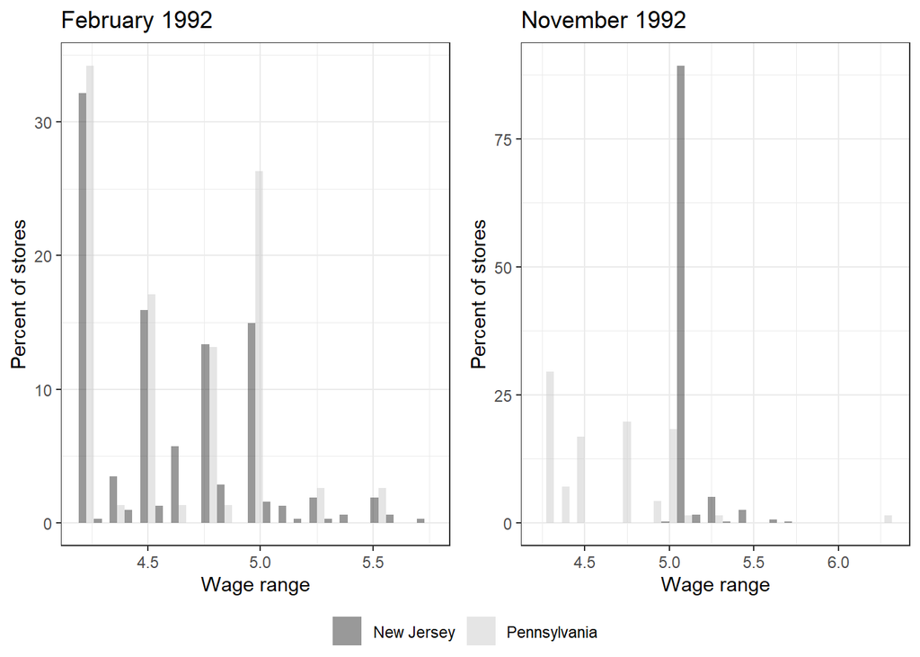

```r
hist.feb <- card_krueger_1994_mod %>%
  filter(observation == "February 1992") %>%
  ggplot(aes(wage_st, fill = state)) +
  geom_histogram(aes(y=c(..count..[..group..==1]/sum(..count..[..group..==1]),
                         ..count..[..group..==2]/sum(..count..[..group..==2]))*100),
                 alpha=0.5, position = "dodge", bins = 23) +
  labs(title = "February 1992", x = "Wage range", y = "Percent of stores", fill = "") +
  scale_fill_grey()

hist.nov <- card_krueger_1994_mod %>%
  filter(observation == "November 1992") %>%
  ggplot(aes(wage_st, fill = state)) +
  geom_histogram(aes(y=c(..count..[..group..==1]/sum(..count..[..group..==1]),
                         ..count..[..group..==2]/sum(..count..[..group..==2]))*100),
                 alpha = 0.5, position = "dodge", bins = 23) +
  labs(title = "November 1992", x="Wage range", y = "Percent of stores", fill="") +
  scale_fill_grey()

ggarrange(hist.feb, hist.nov, ncol = 2,
          common.legend = TRUE, legend = "bottom")
```

### 3.4 Calculating the treatment effect

#### First differences

Before calculating the DiD estimator with OLS, I want to deduce it by means of differencing the mean values of employment (`emptot`) between each group. This is easily done with functions `group_by()` and `summarise()`. We obtain four groups with distinct mean values!

```r
differences <- card_krueger_1994_mod %>%
  group_by(observation, state) %>%
  summarise(emptot = mean(emptot, na.rm = TRUE))

# Treatment group (NJ) before treatment
njfeb <- differences[1,3]

# Control group (PA) before treatment
pafeb <- differences[2,3]

# Treatment group (NJ) after treatment
njnov <- differences[3,3]

# Control group (PA) after treatment
panov <- differences[4,3]
```

#### ATT

The Average Treatment Effect (ATT) in this setting can be determined in two ways:

- calculate the difference between the difference of November and February within NJ and PA

```r
(njnov-njfeb)-(panov-pafeb)
```

```
    emptot
1 2.753606
```

- calculate the difference between the difference of NJ and PA within November and February

```r
(njnov-panov)-(njfeb-pafeb)
```

```
    emptot
1 2.753606
```

This number can be found in row 3 of table 3 in the paper!

#### Digression: counterfactual outcome

Representing the relationship between treatment and control group graphically can be very helpful in order to understand the DiD approach. First, I use the `differences` of variable `emptot` calculated in the previous step for NJ and PJ in February and November. Additionally, we require the outcome of `NJ` if the treatment (raise of the minimum wage) did *not* happen. This is called the **counterfactual outcome** (`nj_counterfactual`). The DiD assumption states that the trends of treatment and control group are identical until the treatment takes place. Hence, without the treatment the employment (`emptot`) of NJ would decline from February to November by the same amount as PA. Since I want to make a graph for this effect I am adding three additional data points to depict an intervention line in the plot which indicates the treatment event.

```r
# Calculate counterfactual outcome
nj_counterfactual <- tibble(
  observation = c("February 1992","November 1992"),
  state = c("New Jersey (Counterfactual)","New Jersey (Counterfactual)"),
  emptot = as.numeric(c(njfeb, njfeb-(pafeb-panov)))
  )

# Data points for treatment event
intervention <- tibble(
    observation = c("Intervention", "Intervention", "Intervention"),
    state = c("New Jersey", "Pennsylvania", "New Jersey (Counterfactual)"),
    emptot = c(19.35, 22.3, 19.35)
  )

# Combine data
did_plotdata <- bind_rows(differences,
                          nj_counterfactual,
                          intervention)
```

#### Line Plot

I am creating a line plot with function `geom_line()` from R package `ggplot2` to illustrate the DiD approach. In November 1992, the distance between the actual and counterfactual employment (`emptot`) of NJ identifies the causal effect of an increase in minimum wages on employment. Note the use of function `geom_label_repel` from R package `ggrepel` here, to align the labels of each line.

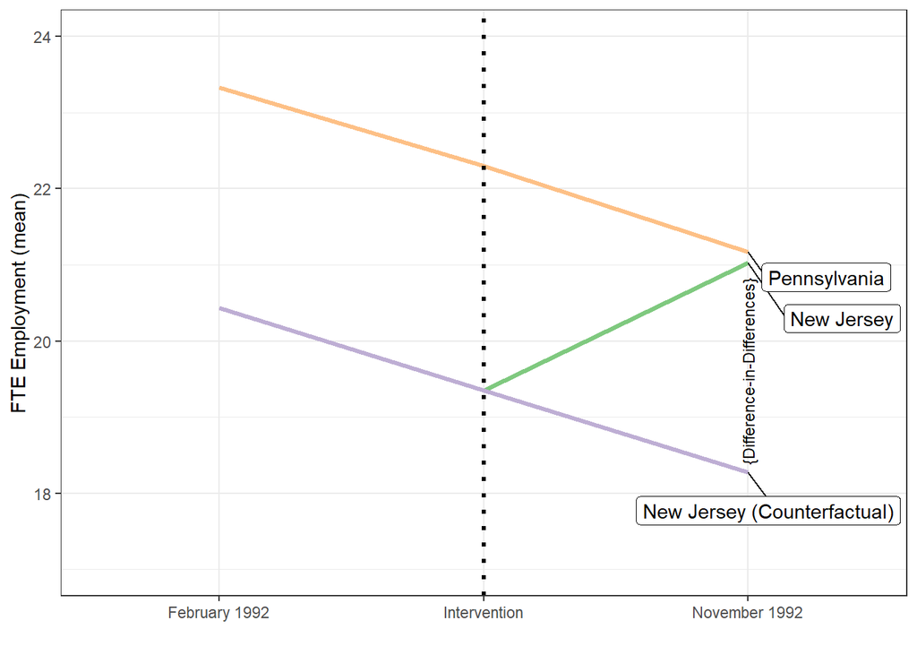

```r
did_plotdata %>%
  mutate(label = if_else(observation == "November 1992", as.character(state), NA_character_)) %>%
  ggplot(aes(x=observation,y=emptot, group=state)) +
  geom_line(aes(color=state), size=1.2) +
  geom_vline(xintercept = "Intervention", linetype="dotted",
             color = "black", size=1.1) +
  scale_color_brewer(palette = "Accent") +
  scale_y_continuous(limits = c(17,24)) +
  ggrepel::geom_label_repel(aes(label = label),
                   nudge_x = 0.5, nudge_y = -0.5,
                   na.rm = TRUE) +
  guides(color=FALSE) +
  labs(x="", y="FTE Employment (mean)") +
  annotate(
    "text",
    x = "November 1992",
    y = 19.6,
    label = "{Difference-in-Differences}",
    angle = 90,
    size = 3
  )
```

### 3.5 Calculating the DiD estimator

#### Dummy variable creation

With linear regression, this result can be achieved very easy. At first, we need to create two dummy variables. One indicates the start of the treatment (`time`) and is equal to zero before the treatment and equal to one after the treatment. The other variable separates the observations into a treatment and control group (`treated`). This dummy variable is equal to one for fast food restaurants located in NJ and equal to zero for fast food restaurants located in PA.

```r
card_krueger_1994_mod <- mutate(card_krueger_1994_mod,
                                time = ifelse(observation == "November 1992", 1, 0),
                                treated = ifelse(state == "New Jersey", 1, 0)
                                )
```

#### Estimation via lm()

The DiD estimator is an interaction between both dummy variables. This interaction can be specified with the `:` operator in the formula of function `lm()` in addition to the individual dummy variables.

*Hint:* Another possibility is to only specify `time*treated` in the formula which adds the individual dummy variables automatically.

```r
did_model <- lm(emptot ~ time + treated + time:treated, data = card_krueger_1994_mod)
summary(did_model)
```

```
Call:
lm(formula = emptot ~ time + treated + time:treated, data = card_krueger_1994_mod)

Residuals:
    Min      1Q  Median      3Q     Max
-21.166  -6.439  -1.027   4.473  64.561

Coefficients:
             Estimate Std. Error t value Pr(>|t|)
(Intercept)    23.331      1.072  21.767   <2e-16 ***
time           -2.166      1.516  -1.429   0.1535
treated        -2.892      1.194  -2.423   0.0156 *
time:treated    2.754      1.688   1.631   0.1033
---
Signif. codes:  0 '***' 0.001 '**' 0.01 '*' 0.05 '.' 0.1 ' ' 1

Residual standard error: 9.406 on 790 degrees of freedom
  (26 observations deleted due to missingness)
Multiple R-squared:  0.007401,  Adjusted R-squared:  0.003632
F-statistic: 1.964 on 3 and 790 DF,  p-value: 0.118
```

The coefficient of `time:treated` is the difference-in-differences estimator. The treatment (raise of the minimum wage) leads on average to an increase of employment (`emptot`) in NJ by **2.75 FTE**.

#### Fixed Effects

Row 4 of table 3 in the study shows a more precise calculation of the DiD estimator, which only includes fast food restaurants that have responses regarding employment (`emptot`) before and after the treatment (this is a so called balanced sample). In RStudio we can get this result by computing a `fixed effects model` which is sometimes also called a `within estimator`. I am using R package `plm` to run this regression with function `plm()` and argument `model = "within"`. Beforehand, the data has to be declared as a *panel* with function `p.dataframe()`. With variable `sheet` each fast food restaurant can be uniquely identified. Additionally, we need the function `coeftest()` from R package `lmtest` in order to obtain the correct standard errors which must be clustered by `sheet`.

```r
# Declare as panel data
panel <- pdata.frame(card_krueger_1994_mod, "sheet")

# Within model
did.reg <- plm(emptot ~ time + treated + time:treated,
               data = panel, model = "within")

# obtain clustered standard errors
coeftest(did.reg, vcov = function(x)
  vcovHC(x, cluster = "group", type = "HC1"))
```

```
t test of coefficients:

              Estimate Std. Error t value Pr(>|t|)
time2          -2.2833     1.2465 -1.8319  0.06775 .
time2:treated   2.7500     1.3359  2.0585  0.04022 *
---
Signif. codes:  0 '***' 0.001 '**' 0.01 '*' 0.05 '.' 0.1 ' ' 1
```

## References

Card, David, and Alan B. Krueger. 1994. “Minimum Wages and Employment: A Case Study of the Fast-Food Industry in New Jersey and Pennsylvania.” *The American Economic Review* 84 (4): 772–93.